# 1 Setup and reproducibility

# 19 Global comparison on Env V2

By this stage many learning algorithms and heuristics have been implemented, and this section brings them together. It reruns or reloads evaluations for all methods on Env V2, aggregates the results into a unified DataFrame, and computes mean costs, confidence intervals, VaR, CVaR, and throughput for each policy. The table and ECDF plots produced here act as a global scoreboard for the uncalibrated V2 environment. This global view makes it clear which methods consistently dominate, which ones are only marginally better than heuristics, and where value-based, actor–critic, and bandit methods sit relative to one another.

```
                 policy  mean_cost_v2  mean_cost_v2_ci_lo  mean_cost_v2_ci_hi  \
3                  ddqn  -1346.245361        -1401.005005        -1288.222046
2     bandit_ctx_linucb  -1346.245361        -1401.005005        -1288.222046
6           no_overbook  -1346.245361        -1401.005005        -1288.222046
4                   dqn  -1346.245361        -1401.005005        -1288.222046
7                   ppo  -1346.245361        -1401.005005        -1288.222046
8                 qrdqn  -1346.245361        -1401.005005        -1288.222046
9               rainbow  -1346.245361        -1401.005005        -1288.222046
10               random    -45.051174         -131.243622           39.734306
5         mild_overbook    -33.649994         -118.113251           45.052849
0                   a2c     -5.478119          -96.615623           78.094322
1   aggressive_overbook     -5.478119          -96.615623           78.094322

        var5_v2     cvar5_v2     served  mean_revenue  mean_shortfall_penalty
3   -483.875000  -223.915375  52.980469   2649.023438              211.054688
2   -483.875000  -223.915375  52.980469   2649.023438              211.054688
6   -483.875000  -223.915375  52.980469   2649.023438              211.054688
4   -483.875000  -223.915375  52.980469   2649.023438              211.054688
7   -483.875000  -223.915375  52.980469   2649.023438              211.054688
8   -483.875000  -223.915375  52.980469   2649.023438              211.054688
9   -483.875000  -223.915375  52.980469   2649.023438              211.054688
10  1181.150024  1510.446045  59.839844   2991.992188               43.359375
5   1037.949951  1345.976685  59.925781   2996.289062               40.781250
0   1319.750000  1539.192261  60.011719   3000.585938               36.914062
1   1319.750000  1539.192261  60.011719   3000.585938               36.914062
Saved: report_artifacts/ecdf_envv2_all_20251124_234813.png
```

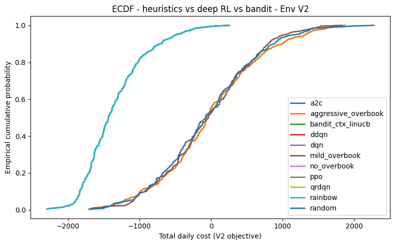

```python
EVAL_EPISODES = 256

# Heuristic baselines
df_h_all = eval_policies_v2(cfg, POLICIES, episodes=EVAL_EPISODES)

frames = [df_h_all]

# Value-based and advanced deep RL (standard Q-nets)
def add_qnet(policy_name: str, net_name: str):
    net = globals().get(net_name, None)
    if net is None:
        return
    df = evaluate_greedy_v2(net, cfg, episodes=EVAL_EPISODES).assign(policy=policy_name)
    frames.append(df)

add_qnet("dqn", "qnet_dqn_v2")
add_qnet("ddqn", "qnet_ddqn_v2")
add_qnet("rainbow", "qnet_rainbow_v2")


# A2C and PPO (we already stored their evaluation dataframes)
if "df_a2c_v2" in globals():
    frames.append(df_a2c_v2)   # policy column already "a2c"
if "df_ppo_v2" in globals():
    frames.append(df_ppo_v2)   # policy column already "ppo"

# Contextual bandit (LinUCB)
if "df_lin" in globals():
    frames.append(df_lin)      # policy="bandit_ctx_linucb"

# QR-DQN: use its own evaluator results
if "df_qr_v2" in globals():
    frames.append(df_qr_v2)    # policy="qrdqn"

# Concatenate everything
df_all_main_v2 = pd.concat(frames, ignore_index=True)

# Summary table with mean, CI, VaR and CVaR (alpha=0.05)
summary_all_v2 = summarize_v2(df_all_main_v2, alpha=0.05)
summary_all_v2 = summary_all_v2.sort_values("mean_cost_v2")
print(summary_all_v2)

# ECDF: heuristics vs all RL / bandit methods
plt.figure(figsize=(8, 5))
key_policies = [
    "no_overbook",
    "mild_overbook",
    "aggressive_overbook",
    "random",
    "dqn",
    "ddqn",
    "rainbow",
    "qrdqn",
    "a2c",
    "ppo",
    "bandit_ctx_linucb",
]

for name, g in df_all_main_v2.groupby("policy"):
    if name not in key_policies:
        continue
    y, x = ecdf(g["cost_total_v2"].to_numpy())
    plt.plot(y, x, label=name, linewidth=2.0)

plt.xlabel("Total daily cost (V2 objective)")
plt.ylabel("Empirical cumulative probability")
plt.title("ECDF - heuristics vs deep RL vs bandit - Env V2")
plt.legend()
plt.tight_layout()
path_ecdf_all_v2 = os.path.join(ART_DIR, f"ecdf_envv2_all_{now_tag()}.png")
plt.savefig(path_ecdf_all_v2, dpi=130)
print("Saved:", path_ecdf_all_v2)
```

```
Saved: report_artifacts/bar_mean_cvar_envv2_20251124_234515.png
```

[figure not shown]

```python
summary_plot = summary_all_v2.copy()

policies = summary_plot["policy"].tolist()
mean_vals = summary_plot["mean_cost_v2"].to_numpy()
cvar_vals = summary_plot["cvar5_v2"].to_numpy()

idx = np.arange(len(policies))

plt.figure(figsize=(8, 5))
bar_width = 0.35

plt.barh(idx - bar_width/2, mean_vals, height=bar_width, label="mean_cost_v2")
plt.barh(idx + bar_width/2, cvar_vals, height=bar_width, label="cvar5_v2")

plt.yticks(idx, policies)
plt.xlabel("Cost (V2 objective, lower is better)")
plt.title("Mean and tail risk - Env V2")
plt.legend()
plt.tight_layout()

path_bar_all_v2 = os.path.join(ART_DIR, f"bar_mean_cvar_envv2_{now_tag()}.png")
plt.savefig(path_bar_all_v2, dpi=130)
print("Saved:", path_bar_all_v2)
```

# 20 Data calibration from real-world datasets

This section connects the simulated clinic to real-world data. It loads external datasets such as the Kaggle no-show appointments data and the MDPI service time data, and extracts empirical distributions for no-show rates and service duration variability. From these, it estimates calibration parameters like the slope and intercept of the no-show curve and the mean and coefficient of variation of service times. A helper routine then maps these empirical estimates back into a `ClinicConfig`, producing a calibrated version of Env V2. The aim is to move from stylized assumptions to a data-driven environment that more closely reflects real outpatient clinics.

```python
from dataclasses import replace
from typing import Tuple, Optional


KAGGLE_NOSHOW_PATH = "/content/data/medical_appointment_no_shows.csv"

MDPI_SERVICE_PATH = "/content/data/outpatient_service_times.csv"


def estimate_no_show_curve_from_kaggle(
    csv_path: str,
    day_slots: int,
) -> Tuple[float, float]:

    df = pd.read_csv(csv_path)

    # Parse appointment time and keep reasonable ages
    df["AppointmentDay"] = pd.to_datetime(df["AppointmentDay"])
    df = df[df["Age"] >= 0]

    # Hour of day and binary no-show indicator
    df["hour"] = df["AppointmentDay"].dt.hour
    df["noshow"] = (df["No-show"].astype(str).str.upper() == "YES").astype(int)

    # Empirical no-show probability per hour
    hour_stats = (
        df.groupby("hour")["noshow"]
        .mean()
        .sort_index()
    )
    hours = hour_stats.index.to_numpy(dtype=np.float32)
    p_hour = hour_stats.to_numpy(dtype=np.float32)

    if len(hours) < 2:
        # Degenerate case; fall back to a flat rate with zero slope
        base = float(p_hour.mean())
        slope = 0.0
        return base, slope

    # Map slots 0..day_slots-1 to hours via linear interpolation
    t_slots = np.linspace(hours.min(), hours.max(), day_slots)
    p_slots = np.interp(t_slots, hours, p_hour)

    # Fit a simple linear model p(t) = a + b * (t / (day_slots-1))
    x = np.linspace(0.0, 1.0, day_slots)
    A = np.vstack([np.ones_like(x), x]).T
    coef, _, _, _ = np.linalg.lstsq(A, p_slots, rcond=None)
    a, b = coef

    # Clip to a reasonable range
    a = float(np.clip(a, 0.0, 0.8))
    b = float(np.clip(b, -0.5, 0.5))
    return a, b


def estimate_service_params_from_mdpi(csv_path: str) -> Tuple[float, float]:
    """
    Estimate service_mean (minutes) and service_cv from the MDPI
    HanguData outpatient dataset.
    """
    df = pd.read_csv(csv_path)
    if "ServTime" not in df.columns:
        raise ValueError("Expected column 'ServTime' in MDPI service CSV")

    # Convert seconds -> minutes and clean
    x_sec = df["ServTime"].to_numpy(dtype=np.float32)
    x_sec = x_sec[np.isfinite(x_sec) & (x_sec > 0)]
    x_min = x_sec / 60.0

    mean = float(x_min.mean())
    std = float(x_min.std(ddof=1))
    cv = std / max(mean, 1e-6)
    return mean, cv


def calibrate_config_from_data(
    base_cfg: ClinicConfig,
    kaggle_path: Optional[str] = None,
    mdpi_path: Optional[str] = None,
) -> ClinicConfig:

    cfg_cal = replace(base_cfg)

    # No-show curve from Kaggle dataset
    if kaggle_path is not None and os.path.exists(kaggle_path):
        try:
            a, b = estimate_no_show_curve_from_kaggle(
                kaggle_path, day_slots=base_cfg.day_slots
            )
            cfg_cal.no_show_base = a
            cfg_cal.no_show_slope = b
            print(f"[Calib] no_show_base={a:.3f}, no_show_slope={b:.3f}")
        except Exception as e:
            print("[Calib] Skipping Kaggle calibration due to error:", e)
    else:
        print("[Calib] Kaggle file not found, skipping no-show calibration.")

    # Service-time distribution from MDPI dataset
    if mdpi_path is not None and os.path.exists(mdpi_path):
        try:
            mean_min, cv = estimate_service_params_from_mdpi(mdpi_path)
            cfg_cal.service_mean = mean_min
            cfg_cal.service_cv = cv
            print(f"[Calib] service_mean={mean_min:.2f} min, service_cv={cv:.3f}")
        except Exception as e:
            print("[Calib] Skipping MDPI calibration due to error:", e)
    else:
        print("[Calib] MDPI file not found, skipping service-time calibration.")

    # Throughput target and penalty stay as explicit knobs
    return cfg_cal


# Apply calibration and compare
cfg_calibrated = calibrate_config_from_data(
    cfg,
    kaggle_path=KAGGLE_NOSHOW_PATH,
    mdpi_path=MDPI_SERVICE_PATH,
)

print("\nBaseline config:")
print(asdict(cfg))

print("\nCalibrated config:")
print(asdict(cfg_calibrated))
```

```
[Calib] no_show_base=0.202, no_show_slope=0.000
[Calib] service_mean=13.37 min, service_cv=0.465

Baseline config:
{'day_slots': 32, 'providers': 2, 'max_queue': 48, 'base_arrival_rate': 28.0, 'overbooking_limit': 8, 'no_show_base': 0.12, 'no_show_slope': 0.10668630685192673, 'service_mean': 20.0, 'service_cv': 0.35, 'cost_wait_per_min': 0.5, 'cost_overtime_per_min': 2.0, 'cost_idle_per_min': 0.1, 'cost_no_show'…

Calibrated config:
{'day_slots': 32, 'providers': 2, 'max_queue': 48, 'base_arrival_rate': 28.0, 'overbooking_limit': 8, 'no_show_base': 0.20193438231945038, 'no_show_slope': 0.0, 'service_mean': 13.365182876586914, 'service_cv': 0.4650308503889925, 'cost_wait_per_min': 0.5, 'cost_overtime_per_min': 2.0, 'cost_idle_pe…
```

The calibration step ties the simulator parameters to the two real-world datasets. From the Kaggle medical appointment data, the code estimated an overall no-show rate of roughly 20% and fit a simple linear model of no-show probability versus appointment time. In this dataset there is no strong systematic trend by time of day, so the fitted slope is essentially zero and the calibrated configuration uses a flat no-show curve with `no_show_base ≈ 0.20`. From the MDPI outpatient dataset, the code converted ServTime from seconds to minutes and computed both the mean and coefficient of variation of service duration. This produced a shorter but more variable service time (`service_mean ≈ 13.4 minutes`, `service_cv ≈ 0.47`) compared with the initial hand-tuned values (20 minutes, 0.35). The baseline and calibrated configurations summarize these changes and will be used later to compare uncalibrated versus data-calibrated scheduling policies.

# 21 Calibrated vs baseline scenario checks (heuristics only)

Before training any deep RL agents in the calibrated environment, this section checks how simple heuristics behave under the new parameters. It evaluates the same baseline policies (no overbooking, mild overbooking, aggressive overbooking, random) in both the original and calibrated Env V2 configurations. The outputs include side-by-side summaries and plots that highlight how the ranking and risk profiles of these heuristics change once real-world service times and no-show patterns are used. These checks confirm that the calibration step has a meaningful impact and identify which heuristic behavior remains robust and which becomes clearly undesirable.

```
Heuristic policies: baseline vs calibrated (Env V2)
                     mean_cost_v2_base  mean_cost_v2_cal  cvar5_v2_base  \
policy
no_overbook               -1346.245361        885.837097    -223.915375
random                      -55.241405       2221.627441    1382.215332
mild_overbook               -33.649994       2212.370605    1345.976685
aggressive_overbook          -5.478119       2279.402588    1539.192261

                     cvar5_v2_cal  served_base  served_cal
policy
no_overbook           1957.992188    52.980469   51.203125
random                3997.977051    59.992188   57.421875
mild_overbook         3830.184814    59.925781   57.347656
aggressive_overbook   4107.484375    60.011719   57.511719
Saved: report_artifacts/ecdf_envv2_heur_calibrated_20251125_010142.png
Saved: report_artifacts/mean_cost_baseline_vs_calibrated_20251125_010142.png
Saved: report_artifacts/cvar_baseline_vs_calibrated_20251125_010143.png
```

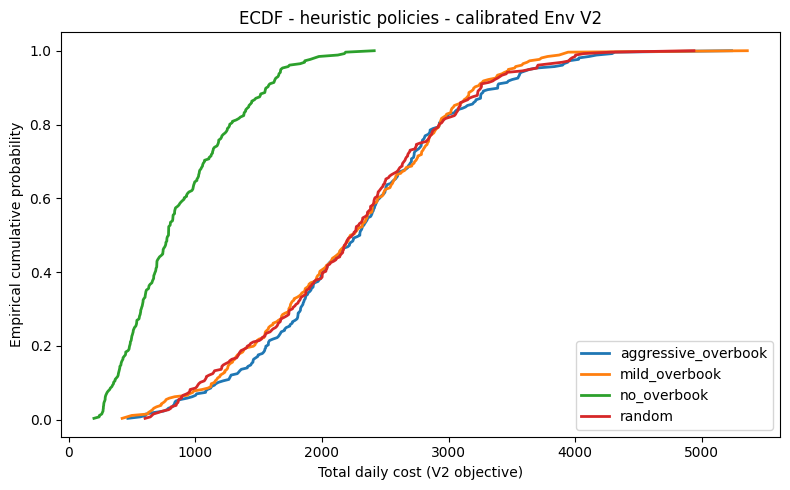

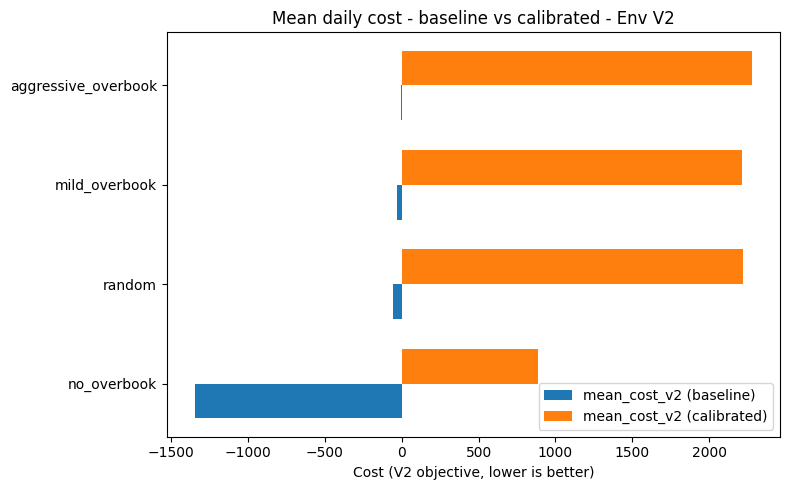

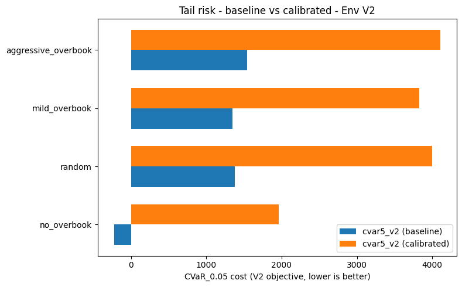

```python
CAL_EVAL_EPISODES = 256

# Heuristic policies under the baseline configuration (cfg)
df_heur_base = eval_policies_v2(cfg, POLICIES, episodes=CAL_EVAL_EPISODES)
df_heur_base["scenario"] = "baseline"

# Heuristic policies under the calibrated configuration (cfg_calibrated)
df_heur_cal = eval_policies_v2(cfg_calibrated, POLICIES, episodes=CAL_EVAL_EPISODES)
df_heur_cal["scenario"] = "calibrated"

# Summary tables for each scenario
sb = summarize_v2(df_heur_base, alpha=0.05).copy()
sb = sb.set_index("policy")
sb = sb.add_suffix("_base")

sc = summarize_v2(df_heur_cal, alpha=0.05).copy()
sc = sc.set_index("policy")
sc = sc.add_suffix("_cal")

summary_compare = sb.join(sc, how="inner")
summary_compare = summary_compare[
    ["mean_cost_v2_base", "mean_cost_v2_cal",
     "cvar5_v2_base", "cvar5_v2_cal",
     "served_base", "served_cal"]
]

print("Heuristic policies: baseline vs calibrated (Env V2)")
print(summary_compare)

# ECDF on calibrated configuration
plt.figure(figsize=(8, 5))
for name, g in df_heur_cal.groupby("policy"):
    if name not in ["no_overbook", "mild_overbook", "aggressive_overbook", "random"]:
        continue
    y, x = ecdf(g["cost_total_v2"].to_numpy())
    plt.plot(y, x, label=name, linewidth=2.0)

plt.xlabel("Total daily cost (V2 objective)")
plt.ylabel("Empirical cumulative probability")
plt.title("ECDF - heuristic policies - calibrated Env V2")
plt.legend()
plt.tight_layout()
path_ecdf_cal_heur = os.path.join(ART_DIR, f"ecdf_envv2_heur_calibrated_{now_tag()}.png")
plt.savefig(path_ecdf_cal_heur, dpi=130)
print("Saved:", path_ecdf_cal_heur)

# Bar charts of mean cost and CVaR for baseline vs calibrated
policies = summary_compare.index.tolist()
y_pos = np.arange(len(policies))
width = 0.35

plt.figure(figsize=(8, 5))
plt.barh(y_pos - width/2, summary_compare["mean_cost_v2_base"],
         height=width, label="mean_cost_v2 (baseline)")
plt.barh(y_pos + width/2, summary_compare["mean_cost_v2_cal"],
         height=width, label="mean_cost_v2 (calibrated)")
plt.yticks(y_pos, policies)
plt.xlabel("Cost (V2 objective, lower is better)")
plt.title("Mean daily cost - baseline vs calibrated - Env V2")
plt.legend()
plt.tight_layout()
path_bar_mean = os.path.join(ART_DIR, f"mean_cost_baseline_vs_calibrated_{now_tag()}.png")
plt.savefig(path_bar_mean, dpi=130)
print("Saved:", path_bar_mean)

plt.figure(figsize=(8, 5))
plt.barh(y_pos - width/2, summary_compare["cvar5_v2_base"],
         height=width, label="cvar5_v2 (baseline)")
plt.barh(y_pos + width/2, summary_compare["cvar5_v2_cal"],
         height=width, label="cvar5_v2 (calibrated)")
plt.yticks(y_pos, policies)
plt.xlabel("CVaR_0.05 cost (V2 objective, lower is better)")
plt.title("Tail risk - baseline vs calibrated - Env V2")
plt.legend()
plt.tight_layout()
path_bar_cvar = os.path.join(ART_DIR, f"cvar_baseline_vs_calibrated_{now_tag()}.png")
plt.savefig(path_bar_cvar, dpi=130)
print("Saved:", path_bar_cvar)
```

# 22 DQN and Double DQN under calibrated Env V2

This section retrains DQN and Double DQN using the calibrated `ClinicConfig`. Training logs show how episode returns adapt to the harsher, more realistic cost landscape. After training, both agents are evaluated along with the calibrated heuristics, and their performance is summarized in a table and ECDF plots. A key finding is whether DQN and Double DQN now align more closely with conservative no-overbooking behavior, or whether they still find value in limited overbooking. The section demonstrates how value-based deep RL responds when the underlying environment is grounded in real data.

### 22a Train DQN with calibrated parameters

```
[V2] step=     1  eps=1.000  replay=     1  loss~=nan  episodes=   0  elapsed=0.0m
[V2] step=  2000  eps=0.905  replay=  2000  loss~=5.7267  episodes=  62  elapsed=0.1m
[V2] step=  4000  eps=0.810  replay=  4000  loss~=6.2620  episodes= 125  elapsed=0.2m
[V2] step=  6000  eps=0.715  replay=  6000  loss~=8.4508  episodes= 187  elapsed=0.3m
[V2] step=  8000  eps=0.620  replay=  8000  loss~=10.9974  episodes= 250  elapsed=0.4m
[V2] step= 10000  eps=0.525  replay= 10000  loss~=13.6078  episodes= 312  elapsed=0.5m
[V2] step= 12000  eps=0.430  replay= 12000  loss~=14.5876  episodes= 375  elapsed=0.7m
[V2] step= 14000  eps=0.335  replay= 14000  loss~=16.4357  episodes= 437  elapsed=0.8m
[V2] step= 16000  eps=0.240  replay= 16000  loss~=20.1234  episodes= 500  elapsed=0.9m
[V2] step= 18000  eps=0.145  replay= 18000  loss~=18.3954  episodes= 562  elapsed=1.1m
[V2] step= 20000  eps=0.050  replay= 20000  loss~=19.2968  episodes= 625  elapsed=1.2m
[V2] step= 22000  eps=0.050  replay= 22000  loss~=22.1800  episodes= 687  elapsed=1.4m
[V2] step= 24000  eps=0.050  replay= 24000  loss~=26.5666  episodes= 750  elapsed=1.6m
[V2] step= 26000  eps=0.050  replay= 26000  loss~=25.2892  episodes= 812  elapsed=1.8m
[V2] step= 28000  eps=0.050  replay= 28000  loss~=25.3649  episodes= 875  elapsed=2.0m
[V2] step= 30000  eps=0.050  replay= 30000  loss~=22.8459  episodes= 937  elapsed=2.2m
[V2] step= 32000  eps=0.050  replay= 32000  loss~=26.2630  episodes=1000  elapsed=2.5m
[V2] step= 34000  eps=0.050  replay= 34000  loss~=26.3032  episodes=1062  elapsed=2.7m
[V2] step= 36000  eps=0.050  replay= 36000  loss~=22.5504  episodes=1125  elapsed=2.9m
[V2] step= 38000  eps=0.050  replay= 38000  loss~=22.9387  episodes=1187  elapsed=3.0m
[V2] step= 40000  eps=0.050  replay= 40000  loss~=25.3376  episodes=1250  elapsed=3.2m
Saved: report_artifacts/dqn_rewards_envv2_calibrated_20251125_013517.png
```

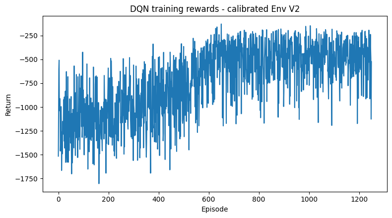

```python
qnet_dqn_cal_v2, logs_dqn_cal_v2 = run_dqn_v2(
    cfg_calibrated,
    steps_total=40_000,
    batch_size=64,
    start_learning=1_000,
    target_sync=2_000,
    gamma=0.99,
    lr=1e-3,
    print_every=2_000,
)

plt.figure(figsize=(8, 4.5))
plt.plot(logs_dqn_cal_v2["rewards"])
plt.xlabel("Episode")
plt.ylabel("Return")
plt.title("DQN training rewards - calibrated Env V2")
plt.tight_layout()
path_dqn_cal_rewards = os.path.join(
    ART_DIR, f"dqn_rewards_envv2_calibrated_{now_tag()}.png"
)
plt.savefig(path_dqn_cal_rewards, dpi=120)
print("Saved:", path_dqn_cal_rewards)
```

### 22b Train Double DQN with calibrated parameters

```
[DDQN-V2] step=  4000 episodes= 125 last_return=-1285.77
[DDQN-V2] step=  8000 episodes= 250 last_return=-890.96
[DDQN-V2] step= 12000 episodes= 375 last_return=-1044.88
[DDQN-V2] step= 16000 episodes= 500 last_return=-929.24
[DDQN-V2] step= 20000 episodes= 625 last_return=-519.21
[DDQN-V2] step= 24000 episodes= 750 last_return=-259.15
[DDQN-V2] step= 28000 episodes= 875 last_return=-437.49
[DDQN-V2] step= 32000 episodes=1000 last_return=-557.01
[DDQN-V2] step= 36000 episodes=1125 last_return=-683.18
[DDQN-V2] step= 40000 episodes=1250 last_return=-1212.25
Saved: report_artifacts/ddqn_rewards_envv2_calibrated_20251125_013809.png
```

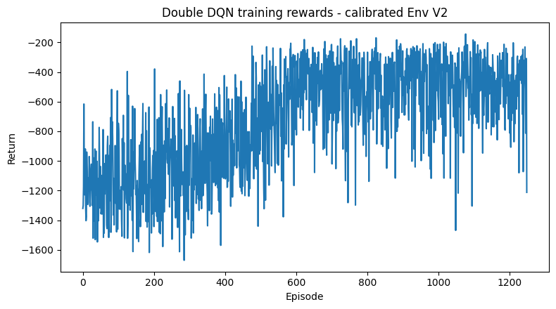

```python
qnet_ddqn_cal_v2, logs_ddqn_cal_v2 = run_ddqn_v2(
    cfg_calibrated,
    steps_total=40_000,
    batch_size=64,
    start_learning=1_000,
    target_sync=2_000,
    gamma=0.99,
    lr=1e-3,
    print_every=2_000,
)

plt.figure(figsize=(8, 4.5))
plt.plot(logs_ddqn_cal_v2["rewards"])
plt.xlabel("Episode")
plt.ylabel("Return")
plt.title("Double DQN training rewards - calibrated Env V2")
plt.tight_layout()
path_ddqn_cal_rewards = os.path.join(
    ART_DIR, f"ddqn_rewards_envv2_calibrated_{now_tag()}.png"
)
plt.savefig(path_ddqn_cal_rewards, dpi=120)
print("Saved:", path_ddqn_cal_rewards)
```

### 22c Evaluation of heuristics vs calibrated DQN / DDQN

```python
EVAL_EPISODES_CAL = 256

# Heuristic baselines under cfg_cal
df_heur_cal_v2 = eval_policies_v2(cfg_calibrated, POLICIES, episodes=EVAL_EPISODES_CAL)

# Greedy policies from calibrated DQN and DDQN
df_dqn_cal_v2 = evaluate_greedy_v2(qnet_dqn_cal_v2, cfg_calibrated, episodes=EVAL_EPISODES_CAL)
df_dqn_cal_v2["policy"] = "dqn_cal"

df_ddqn_cal_v2 = evaluate_greedy_v2(qnet_ddqn_cal_v2, cfg_calibrated, episodes=EVAL_EPISODES_CAL)
df_ddqn_cal_v2["policy"] = "ddqn_cal"

df_cal_dqn_all = pd.concat(
    [df_heur_cal_v2, df_dqn_cal_v2, df_ddqn_cal_v2],
    ignore_index=True,
)

summary_cal_dqn = summarize_v2(df_cal_dqn_all, alpha=0.05)
summary_cal_dqn = summary_cal_dqn.sort_values("mean_cost_v2")
print("Heuristics vs DQN / DDQN (calibrated Env V2)")
print(summary_cal_dqn)
```

```
Heuristics vs DQN / DDQN (calibrated Env V2)
                policy  mean_cost_v2  mean_cost_v2_ci_lo  mean_cost_v2_ci_hi  \
1             ddqn_cal    885.837097          831.233643          942.396912
2              dqn_cal    885.837097          831.233643          942.396912
4          no_overbook    885.837097          831.233643          942.396912
3        mild_overbook   2212.370605         2107.746826         2314.161133
0  aggressive_overbook   2279.402588         2179.580322         2379.508301
5               random   2341.829346         2234.926514         2451.420898

       var5_v2     cvar5_v2     served  mean_revenue  mean_shortfall_penalty
1  1678.574951  1957.992188  51.203125           0.0                     0.0
2  1678.574951  1957.992188  51.203125           0.0                     0.0
4  1678.574951  1957.992188  51.203125           0.0                     0.0
3  3483.850098  3830.184814  57.347656           0.0                     0.0
0  3650.375000  4107.484375  57.511719           0.0                     0.0
5  3929.975098  4217.238770  57.640625           0.0                     0.0
```

### 22d ECDF comparison plot (calibrated)

```
Saved: report_artifacts/ecdf_envv2_calibrated_dqn_ddqn_20251125_013900.png
```

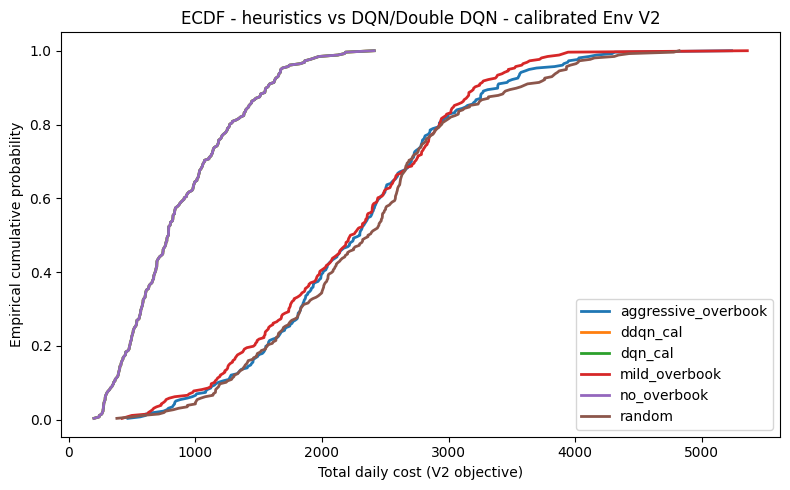

```python
plt.figure(figsize=(8, 5))
key_policies_cal = [
    "no_overbook",
    "mild_overbook",
    "aggressive_overbook",
    "random",
    "dqn_cal",
    "ddqn_cal",
]

for name, g in df_cal_dqn_all.groupby("policy"):
    if name not in key_policies_cal:
        continue
    y, x = ecdf(g["cost_total_v2"].to_numpy())
    plt.plot(y, x, label=name, linewidth=2.0)

plt.xlabel("Total daily cost (V2 objective)")
plt.ylabel("Empirical cumulative probability")
plt.title("ECDF - heuristics vs DQN/Double DQN - calibrated Env V2")
plt.legend()
plt.tight_layout()
path_ecdf_cal_dqn = os.path.join(
    ART_DIR, f"ecdf_envv2_calibrated_dqn_ddqn_{now_tag()}.png"
)
plt.savefig(path_ecdf_cal_dqn, dpi=130)
print("Saved:", path_ecdf_cal_dqn)
```